# Sesion 24 - Datos Categoricos y Modelos de Grafos Probabilisticos Parte 7/7

Juan Carlos Martínez-Ovando

Maestría en Ciencia de Datos

Primavera 2019

# 1 Objetivos

En esta sesion:

- Estudiaremos definciones, propiedades y extensiones de los **modelos de grafos probabilisticos dirigidos** para datos categoricos.
- Estudiaremos definiciones y propiedades inferencias de los **modelos de grafos triangulados**.
- Implementaremos las soluciones con las librerias `gRbase` y `gRim`:

```
if(!requireNamespace("BiocManager", quietly = TRUE)){install.packages("BiocManager")}
BiocManager::install("graph", version = "3.8")
BiocManager::install("RBGL", version = "3.8")
BiocManager::install("Rgraphviz", version = "3.8")

install.packages("gRbase", dependencies=TRUE)
install.packages("gRim", dependencies=TRUE)
```

# 2 Redes bayesianas

> **Defincion:-** Una `red bayesiana` (`BN`, por sus siglas en ingles) es un `grafo probabilistico` basado en un `DAG`.

> Un `BN` satisface condiciones de `independencia condicional` en subgrafos contenidos en `BN`.

## 2.1 Ejemplo

Consideremos un ejemplo en el que se conectan tres dimensiones con base en las siguientes `premisas`:

> Tener gripe ($G$) puede causar una temperatura elevada ($F$). La temperatura elevada puede causar un dolor de cabeza ($D$).

La representacion del `grafo` asociado con estas `premisas` es

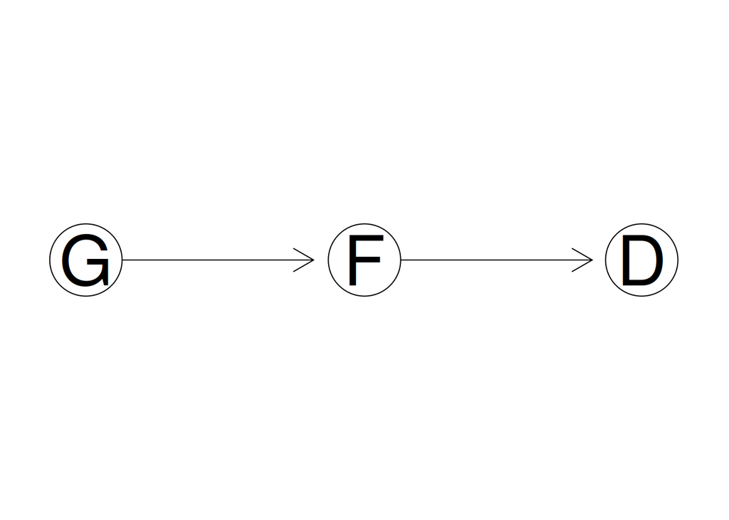

```r
gp.GFD <-dag(~ G + F:G + D:F)
plot(gp.GFD, "circo")
```

Definmos el conjunto de `vertices` como
$$V=\{G,F,D\},$$
con el `vector aleatorio`,
$$X=(X_v)_{v\in V}=(X_G,X_F,X_D),$$
donde
$$\mathcal{X}_v = \{1,2\},$$
con
$$X_v=\begin{cases}1, &\text{ no }v,\\2, &\text{ s }v,\end{cases}$$
para $v\in V$.

La regla de probabilidad asociada con $E$ es
$$\begin{eqnarray}
p(x) & = & p(x_G) p(x_F|x_G) p(x_D|x_F) \\
& = & p(G)p(F|G)p(D|F).
\end{eqnarray}$$

### 2.1.1 Casos

- Es facil verificar que $D$ (dolor de cabeza) es condicionalmente independiente de $G$ (gripe), condicional en $F$ (fiebre), i.e.
  $$(X_G \mathrel{\text{$\perp\mkern-10mu\perp$}}X_D) | X_F,$$
  o, analogamente,
  $$(G \mathrel{\text{$\perp\mkern-10mu\perp$}}D) | F.$$

### 2.1.2 Aprendizaje

Dado que hemos encontrado que un paciente tiene $D$ (dolor de cabeza), i.e.
$$X_{D,1}=2,$$
podemos calcular/actualizar las probabilidades condicionales para $X_{G,1}$ y $X_{F,1}$ dado $X_{D,1}=2$.

### 2.1.3 Componentes inciales

Antes de observar `evidencia`, necesitamos definir `probabilidades iniciales` con base en la descomposicion que vimos anteriormente:

```r
p.G <- parray("G", levels=2, values=c(.99,.01))
(p.G)
```

```
## G
##   G1   G2
## 0.99 0.01
## attr(,"class")
## [1] "parray" "array"
```

```r
p.FgG <- parray(c("F","G"), levels=c(2,2), values=c(.05,.95, .999,.001))
(p.FgG)
```

```
##     G
## F      G1    G2
##   F1 0.05 0.999
##   F2 0.95 0.001
## attr(,"class")
## [1] "parray" "array"
```

```r
p.DgF <- parray(c("D","F"), levels=c(2,2), values=c(.20,.80, .99,.01))
(p.DgF)
```

```
##     F
## D     F1   F2
##   D1 0.2 0.99
##   D2 0.8 0.01
## attr(,"class")
## [1] "parray" "array"
```

La representacion de la `tabla de contendencia` $G\times F\times D$, en terminos de las `probabilidades iniciales` asociadas con el `grafo de probabilidad`, son

```r
p.GF <- tableMult(p.G, p.FgG)
p.DFD <- tableMult(p.GF, p.DgF)
p.DFD
```

```
## , , G = G1
##
##     F
## D        F1       F2
##   D1 0.0099 0.931095
##   D2 0.0396 0.009405
##
## , , G = G2
##
##     F
## D          F1      F2
##   D1 0.001998 9.9e-06
##   D2 0.007992 1.0e-07
```

Estas `probabilidades conjuntas`, pueden escribirse como un `data.frame`

```r
p.DFD.df <- as.data.frame.table(p.DFD)
colnames(p.DFD.df) <- c("G","F","D","p_v")
p.DFD.df
```

```
##    G  F  D       p_v
## 1 D1 F1 G1 0.0099000
## 2 D2 F1 G1 0.0396000
## 3 D1 F2 G1 0.9310950
## 4 D2 F2 G1 0.0094050
## 5 D1 F1 G2 0.0019980
## 6 D2 F1 G2 0.0079920
## 7 D1 F2 G2 0.0000099
## 8 D2 F2 G2 0.0000001
```

## 2.2 Comentarios

> Las probabilidades actualizadas por la `observacion/configuracion` $X_{D,1}=2$, son generalmente dificiles de calcular directamente. Mas aun, cuando deseamos calcular la `actualizacion` con un conjunto `grande` de `datos/configuraciones` observadas.

> **Invitacion:-** Les invito a realizar la actualizacion anterior.

> **Comentario:-** Las actualizacion tendran `calculo facil` si representamos el modelo como un `grafo triangulado`.

# 3 Triangulacion y tablas de contingencia

## 3.1 Definiciones

> **Defincion:-** Un grafo es `triangular` (o `descomponible`) si no contiene ciclos de orden $n\geq 4$.

Recordemos que los `ciclos` corresponden a las `trayectorias mas cortas` de regresar a un `nodo/vertice` dado.

La `longitud del ciclo` es el numero de `bordes` en la `trayectoria`.

## 3.2 Ejemplos

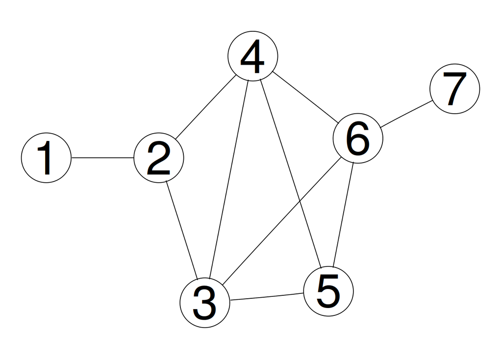

```r
gt <- ug(~ 1:2 + 2:3:4 + 3:4:5:6 + 6:7)
plot(gt, "circo")
```

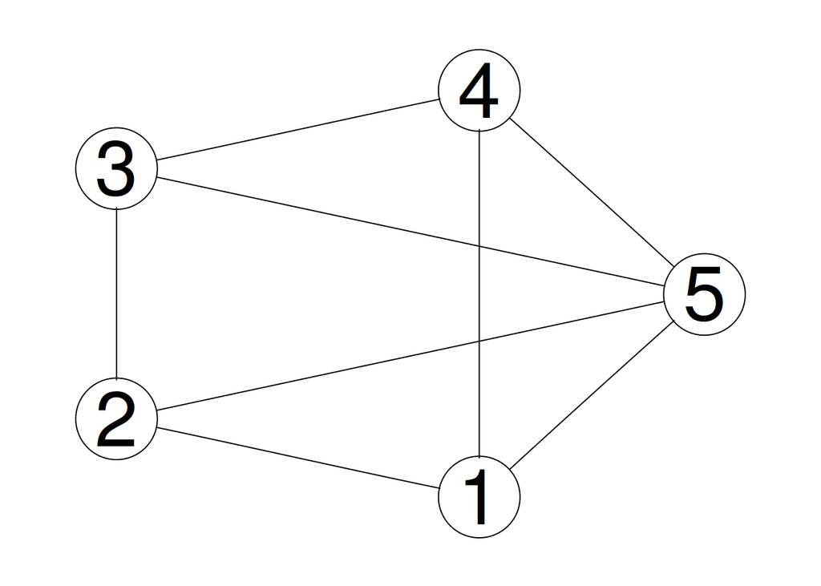

```r
gnt <- ug(~1:2:5 + 2:3:5 + 3:4:5 + 4:1:5)
plot(gnt,"circo")
```

> **Defincion:-** Un `modelo loglinear jerarquico` con clase generadora
> $$\mathcal{C}_{G}=\{G_1,\ldots,G_Q\}$$
> es `grafico` si los elementos generadores $G_j\in\mathcal{C}_G$ son `cliques` del `grafo dependiente`.

> **Definicion:-** Un `modelo loglineal grafico` es `triangulado` si el `grafo dependiente` es `triangulado`.

## 3.3 Conexion c/ modelos loglineales

El modelo `loglineal dependiente` con interacciones dadas por la clase generadora
$$\mathcal{C}_1 = \{ \{1,2,3\}, \{2,3,4\} \}$$
es `grafico`. Adicionalmente, es `triangular`.

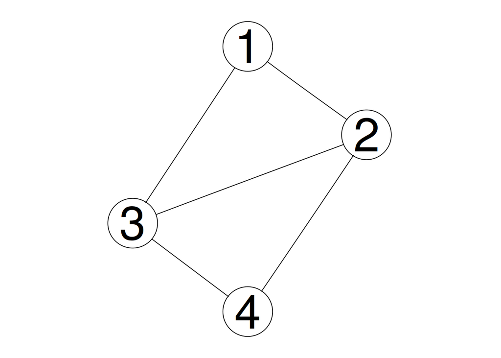

```r
dg.g <- ug(~1:2:3 + 2:3:4)
plot(dg.g)
```

Pero el modelo con la `clase generadora`
$$\mathcal{C}_2=\{ \{1,2\}, \{1,3\}, \{2,3,4\} \},$$
no es `grafico`.

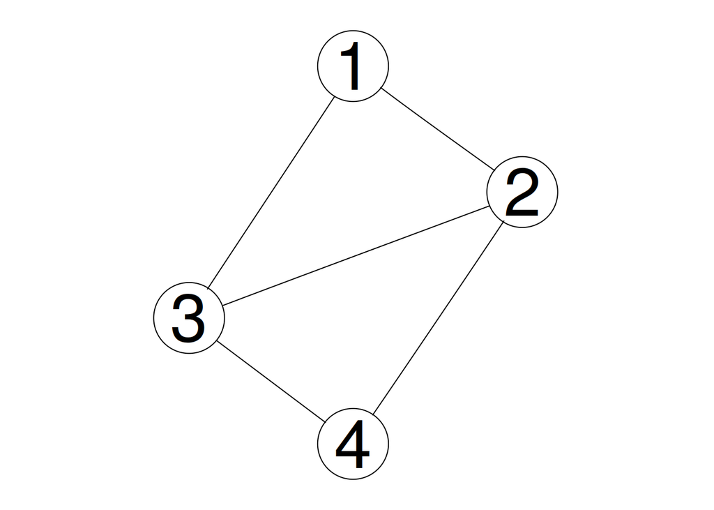

```r
dg.ng <- ug(~1:2 + 1:3 + 2:3:4)
plot(dg.ng)
```

Aunque ambos tienen los siguientes `cliques` asociados:
$$\{ \{1,2,3\}, \{2,3,4\} \}.$$

# 4 Aprendizaje estadistico (frecuentista)

> La idea de trabajar con `grafos triangulares` es la de poder tener simplificaciones de las `masas de probabilidad` $p(x_v),$ de manera que `estimadores maximo verosimiles puntuales` sean faciles de obtener.

## 4.1 Ejemplo

Observaciones:

- $\hat{\theta}_{ijk\cdot} = \frac{n_{ijk\cdot}}{n}$ es el EMV para $\theta_{ijk\cdot}$ para la `tabla de contingencia marginal` $\{1,2,3\}$.
- $\hat{\theta}_{\cdot jkl} = \frac{n_{i\cdot jkl}}{n}$ es el EMV para $\theta_{\cdot jkl}$ para la `tabla de contingencia marginal` $\{2,3,4\}$.
- $\hat{\theta}_{\cdot jk\cdot} = \frac{n_{\cdot jk\cdot}}{n}$ es el EMV para $\theta_{\cdot jk\cdot}$ para la `tabla de contingencia marginal` $\{2,3\}$.

## 4.2 Resultado

Para un `modelo grafo triangulado`, se cumple la siguiente descomposicion:
$$\hat{\theta}_{v} = \frac{\prod_{ \{C:\text{clique}\} }\hat{\theta}_{C}}{\prod_{ \{S:\text{sep}\} }\hat{\theta}_{S}},$$
donde
$$\hat{\theta}_A = \frac{n_A}{n},$$
para todo $A\subset V$ conjuntos `cliques` y `separadores`.

# 5 Ejemplo de sesiones previas

```r
g3 <- ug(~ 1:2 + 2:3:4 + 3:5 + 4:5 + 6)

suppressMessages(library("gRbase"))
data(lizardRAW, package="gRbase")

data <- lizardRAW
colnames(data) <- c("X2","X3","X1")
data <- data[,c("X1","X2","X3")]
data.tc <- table(data)
data.prob <- table(data)/sum(table(data))
```

Retomemos el ejemplo de los `409` lagartos, considerando el modelo dado por la `clase generadora`
$$\{ \{1,2\}, \{1,3\} \}.$$

Es decir, el `modelo de grafo`

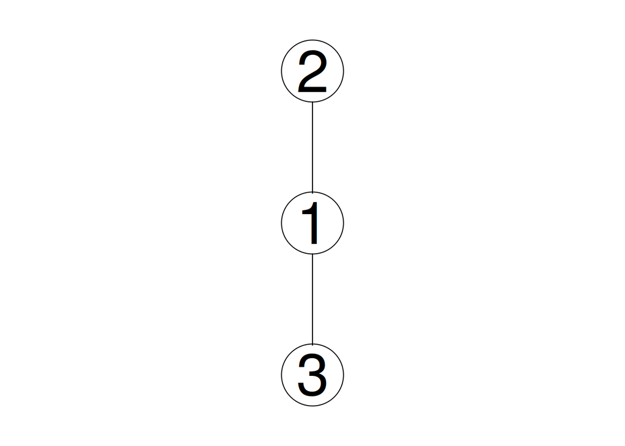

```r
dg.lagarto <- ug(~2:1 + 3:1)
plot(dg.lagarto)
```

En este caso, tenemos las siguientes `tablas de contingencia marginales`:

- Tabla de contingencia marginal para $\{1,2\}$ i.e. $\{X_1,X_2\}$

```r
n.21 <- tableMargin(data.tc, c("X2","X1"))
n.21
```

```
##      X1
## X2    anoli dist
##   <=4   118  134
##   >4     46  111
```

- Tabla de contingencia marginal para $\{1,3\}$ i.e. $\{X_1,X_3\}$

```r
n.31 <- tableMargin(data.tc, c("X3","X1"))
n.31
```

```
##         X1
## X3       anoli dist
##   <=4.75   121  143
##   >4.75     43  102
```

- Tabla de contingencia marginal para $\{1\}$ i.e. $\{X_1\}$

```r
n.1 <- tableMargin(data.tc, c("X1"))
n.1
```

```
## X1
## anoli  dist
##   164   245
```

## 5.1 Casos esperados

La `tabla de contingencia` con `conteos esperados` celda-por-celda se calcula como

```r
e.v <- tableDiv( tableMult(n.21, n.31), n.1)
e.v
```

```
## , , X2 = <=4
##
##        X3
## X1        <=4.75    >4.75
##   anoli 87.06098 30.93902
##   dist  78.21224 55.78776
##
## , , X2 = >4
##
##        X3
## X1        <=4.75    >4.75
##   anoli 33.93902 12.06098
##   dist  64.78776 46.21224
```

```r
sum(e.v)
```

```
## [1] 409
```

*versus* la `tabla de contingencia muestral`,

```r
data.tc
```

```
## , , X3 = <=4.75
##
##        X2
## X1      <=4 >4
##   anoli  86 35
##   dist   73 70
##
## , , X3 = >4.75
##
##        X2
## X1      <=4 >4
##   anoli  32 11
##   dist   61 41
```

```r
sum(data.tc)
```

```
## [1] 409
```

> **Observacion:-** La `tabla de contingencia estimada` es util para producir `predicciones puntuales` celda-a-celda.

## 5.2 Prueba de indenpendencia

Antes de realizar predicciones, es conveniente contrastar el modelo inducido por la `clase generadora` mencionada,
$$\mathcal{C}_1=\{ \{1,2\}, \{1,3\}\}$$
*versus* el modelo con la `clase generadora saturado`
$$\mathcal{C}_0=\{ \{1\}, \{2\}, \{3\}, \{1,2\}, \{1,3\}, \{2,3\}, \{1,2,3\} \}.$$

> Es decir, `contrastar estadisticamente` si existen interacciones/comovimientos entre las dimensiones o no.

> **Comentario:-** En caso de no existir comovimientos (a.k.a. `existir independencia`), las predicciones se realizarian mediante productos de `distribuciones multinomiales` dimension-a-dimension.

La funcion `ciTest()` nos permite realizar la prueba de hipotesis correspondiente:

```r
suppressMessages(library("gRim"))
ciTest(data.tc, set=c("X2","X3","X1"))
```

```
## Testing X2 _|_ X3 | X1
## Statistic (DEV):    2.026 df: 2 p-value: 0.3632 method: CHISQ
## Slice information:
##   statistic p.value df    X1
## 1     0.178  0.6731  1 anoli
## 2     1.848  0.1741  1  dist
```

La prueba anterior sirve para `contrastar` la hipotesis:
$$(X_2 \mathrel{\text{$\perp\mkern-10mu\perp$}}X_3) | X_1.$$

> **Interpretacion:-** La prueba, grosso modo, se contruye como una prueba de independencia condicional en una `tabla de contingencia` de tres dimensiones, `$A \times B \times S$, dado $S$.

> **Definicion:-** Asociada con la prueba anterior, el `estadistico de devianza` se calcula como
> $$\begin{eqnarray}
> D(\mathcal{C}_1,\mathcal{C}_0)
> & = & 2 \sum_{ijk} n_{ijk} \log \frac{n_{ijk}}{m_{ijk}} \\
> & = & \sum_{i} 2 \sum_{jk} n_{ijk} \log \frac{n_{ijk}}{\hat{m}_{ijk}} \\
> & = & \sum_{i} D_i(\mathcal{C}_1,\mathcal{C}_0), \\
> \end{eqnarray}$$
> donde $D_k(\mathcal{C}_1,\mathcal{C}_0)$ denota la `devianza` de la `tabla de contingencia marginal` de $\{X_2,X_3\}$ condicional a cada configuracion
> $$X_1=i \in \mathcal{X}_1.$$

En la ecuacion anterior:

- Los valores $n_{ijk}$ corresponden a los `conteos esperados` del `modelo saturado`.
- Los valores $m_{ijk}$ corresponden a los `conteos esperados` del `modelo por contrastar`.

Recalculamos la prueba de hipotesis:

```r
ciTest.23d1 <- ciTest(data.tc, set=c("X2","X3","X1"))
ciTest.23d1
```

```
## Testing X2 _|_ X3 | X1
## Statistic (DEV):    2.026 df: 2 p-value: 0.3632 method: CHISQ
## Slice information:
##   statistic p.value df    X1
## 1     0.178  0.6731  1 anoli
## 2     1.848  0.1741  1  dist
```

El `estadistico de prueba` tiene distribucion asintotica $\chi_{\text{df}}$ con $\text{df}$ grados de libertad. Estos, en un contexto general, se definen como
$$\text{df}_{1} = \left( \#\{j : n_{ij\cdot} > 0\} − 1\right) \times \left(\#\{k : n_{i\cdot k} > 0\} − 1\right),$$
i.e. en nuestro ejemplo,
$$\text{df}=2.$$

### 5.2.1 Devianzas marginales

Las devianzas marginales para la `prueba de independencia` calculadas para cada configuracion de
$$X_1=i,$$
se otienen de `ciTest()` de la siguiente forma:

```r
ciTest.23d1$slice
```

```
##   statistic   p.value df    X1
## 1 0.1779795 0.6731154  1 anoli
## 2 1.8476671 0.1740550  1  dist
```

> Al abrir la tabla de contingencia en rebanadas en una dimension, abrimos la posibilidad de tener lecturas complementarias distintas al agredado.

Por ejemplo, el cuantil $\chi_{\text{df}}$ al $95$ porciento se calcula como

```r
chi.95.df1 <- qchisq(.95, df=1)
chi.95.df1
```

```
## [1] 3.841459
```

```r
chi.95.df2 <- qchisq(.95, df=2)
chi.95.df2
```

```
## [1] 5.991465
```

Comparando estos `valores` con los `estadisticos de las devianzas marginales y agregadas` vemos que las `hipotesis de independencia condicional` no se rechazan.

# 6 Comentarios finales

## 6.2 Siguiente sesion

- Estudio/uso de `algoritmos bayesianos predictivos automaticos`.
- Estudio de `modelos de grafos causales`.